# Canonical trait mapping: pipeline, validation, and the first ukb-b round

Mapping free-text GWAS trait labels to EFO terms with BioLORD retrieval and the Jev chooser (issues #161, #185)

Published

September 28, 2026

## Summary

The Canonical Trait Mapping Table maps free-text trait labels, such as UK Biobank field descriptions, to ontology terms, so Analyses from different sources can be joined on a shared trait. This report covers:

- the curation pipeline built for epic #161, including the issue #185 changes that use the UK Biobank field structure and Showcase context;
- its validation against the GWAS Catalog’s own EFO curation (Store OGS-00011);
- the first production round over the ukb-b queue (run before the #185 changes, so its numbers reflect the earlier top-10 retrieval without the ICD-10 or field-context channels).

**Headline results**

**ImportantIssues found only by running on real data**

Several defects passed a hermetic test suite of more than 500 tests. They showed up only against the live Jev API, the real EFO release, or the real embedding server. These classes of failure need live smoke tests. They are listed in Issues found by live runs.

## The pipeline

```
flowchart LR
  M[Release Manifests<br/>analyses.tsv] --> G[gap-scan<br/>unmapped labels]
  O[EFO v3.94.0 OBO] --> I[ontology index<br/>CURIEs + ICD-10 xrefs]
  S[UKB Showcase schema] --> U[ukb parse<br/>value text + question context]
  I --> EO[embed-ontology<br/>BioLORD-2023, once]
  G --> ET[embed-traits<br/>per round]
  G --> U
  I --> C[candidates<br/>lexical + icd10 + semantic<br/>phenotype-only, RRF, top 100]
  U --> C
  EO --> C
  ET --> C
  C --> CH[choose<br/>one Jev request per trait<br/>+ field question context]
  U --> CH
  CH --> R[reduce<br/>proposals, ledger, buckets]
  R --> P[promote<br/>thresholds gate]
  P --> T[(mapping.tsv)]
  P --> Q[review queue]
  P --> N[no-suitable-term]
```

Each stage is an idempotent `pixi run -e curation round-*` task. It reads its pins (ontology release, embedding model and store `build_id`, chooser model, thresholds) from `<round-dir>/round.yaml`, and it refuses to run when an artifact contradicts a pin.

[output not shown]

### Design decisions

**One request per trait, not packed batches.** TypeSafe has no asynchronous or discounted batch API. We compared packing 19 traits into one request with sending them individually:

- Packing saved about 20% of input tokens: roughly 3 cents over the whole ukb-b queue.
- Packing changed the answers:
  - single and packed requests disagreed on 1 of 19 choices;
  - two packed orderings of the same traits disagreed on 2 of 19;
  - confidence moved by up to 0.39 depending on which other traits shared the request.

We chose per-trait requests: each answer depends only on its own shortlist, can be cached, and can be retried on its own.

**Always offer `none_suitable`.** Many ukb-b labels have no EFO term, and others have one that retrieval missed; without an explicit way to abstain the chooser has to pick the nearest related term. In the validation run, when the Catalog’s term was *not* in the shortlist, Jev abstained on 77.5% of labels rather than picking a wrong term.

**Thresholds taken from validation, not guessed.** The defaults (0.85 / 0.20) were kept after calibration (below). Above confidence 0.8 the margin threshold is redundant: a confident pick has a large margin by construction.

**Retrieve coded fields on their value, not the whole field string.** A coded ukb-b label mixes a field title, a code, and a description (`diagnoses - main icd10: c20 malignant neoplasm of rectum`). The string-matching and embedding channels retrieve on the description alone, while the raw label remains the lookup key, so the exact-match contract of `mapping.tsv` is unchanged.

**ICD-10 cross-references are a direct channel.** EFO terms carry `ICD10`/`ICD10CM`/`ICD10WHO` xrefs. A label that carries an ICD-10 code looks the code up directly, falling back to its 3-character chapter, so a diagnosis maps to its term even when no string overlaps. Round 1’s `c61 malignant neoplasm of prostate`, `k59.0 constipation` and `h00.1 chalazion` were abstained because no candidate was retrieved; the xref channel shortlists `prostate cancer`, `constipation disorder` and `chalazion` directly.

**Only phenotype-bearing terms are offered.** Cell lines, cell types, chemicals, taxa, anatomy and proteins (prefixes `BTO/PO/CHEBI/NCBITaxon/UBERON/CL/CLO/PR`, plus EFO’s own cell-line subtree) are dropped before ranking. Checked against OGS-00011 before adoption: **0 of the 934** Catalog truth terms fall in an excluded branch, so the restriction cannot drop a Catalog term.

**The chooser reads the field’s question.** For non-coded fields the Showcase schema supplies the actual question, its category path and units, passed to Jev as per-trait context alongside the label. For coded fields the notes are boilerplate, so they are deliberately not sent.

**Shortlist size is 100.** A hundred candidates still fit Jev’s 60k-token / 1 MiB input budget, and a wider net raises the chance the correct term is offered.

## Issues found by live runs

Every row below had passing unit tests at the time. Each one is now fixed and covered by a regression test.

| Issue | Found by | Impact if unfixed |
| --- | --- | --- |
| Jev returns probabilities rounded to 2 decimal places, so a 21-option distribution summed to 0.99 and failed a 1e-6 check | Live Jev pilot, 25 labels | 3 of 25 paid answers were thrown away |
| EFO v3.94.0 spells native ids as `efo:EFO_0003939`; every manifest uses `EFO:0003939` | Live pilot shortlist | No mapping would ever match a source id, and every promoted row would have had a non-canonical id |
| 12% of shortlist rows (3,055 of 25,020) were obsolete terms | ukb-b shortlist inspection | Obsolete terms could be chosen and written to the table |
| TEI accepts at most 32 inputs per request; the client sent 128 | Live TEI server | Every embedding request would fail |
| 6 imported terms have no label, synonym, or definition; TEI refuses empty input | Live TEI server | Ontology embedding aborted |
| The client posted to the base URL, not `/v1/embeddings` | Live TEI server | Every embedding request would fail |
| 332 GWAS Catalog rows map one trait to several terms (a comma-joined IRI list) | OGS-00011 harvest | Each would score as a certain error, biasing calibration down |
| `choose` and `reduce` computed different fingerprints for a Jev round | Code review | A real round could never complete |
| The cost cap reset on every rerun and was overshot by requests in flight | Code review | Unbounded spend across resumed runs |
| A stub or fixture round could promote into the tracked mapping table (the default resource) | A reviewer running the runbook | Test rows written to `mapping.tsv` and the version bumped |
| A curator `amend` could write `none_suitable` into the table | Code review | The sentinel stored as a term |

## Validation on OGS-00011

OGS-00011 is the GWAS Catalog EUR hybrid Store. Almost every Analysis carries a curator-assigned EFO term (`source_provided`). We harvested its single-term mappings, excluding 332 multi-term rows. That left 2,228 distinct labels, which we ran through exactly the same round as production.

The Catalog’s curation is a **silver standard**: it is often deliberately broad (e.g. *pulmonary function measurement* for FEV1). A pick that differs from it is not necessarily wrong. That is why confident disagreements were reviewed individually below.

### Retrieval

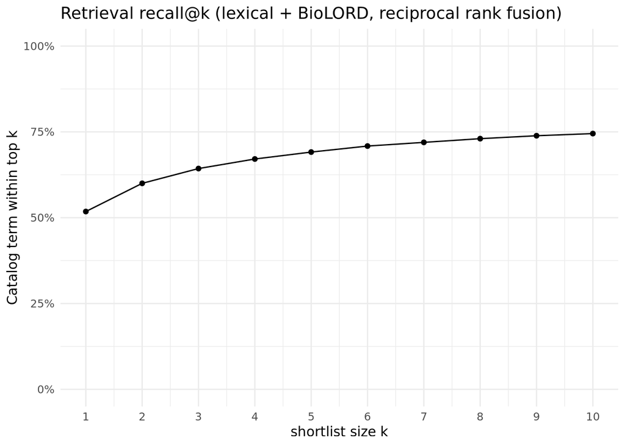

| Stratum | Labels | Recall@10 |
| --- | --- | --- |
| analyte_measurement | 1356 | 71.8% |
| disease | 387 | 74.9% |
| other | 485 | 81.9% |

Retrieval sets the ceiling on accuracy: the chooser can only pick from the shortlist. The Catalog’s exact term is missing for 25.5% of labels. Often a close alternative is present instead, as the adjudication shows.

### Choice

| Retrieval | Jev outcome | Labels | Share |
| --- | --- | --- | --- |
| Catalog term not shortlisted | abstained (none_suitable) | 440 | 77.5% |
| Catalog term not shortlisted | picked another term | 128 | 22.5% |
| Catalog term shortlisted | abstained (none_suitable) | 274 | 16.5% |
| Catalog term shortlisted | picked another term | 207 | 12.5% |
| Catalog term shortlisted | picked the Catalog term | 1179 | 71.0% |

### Thresholds: precision against yield

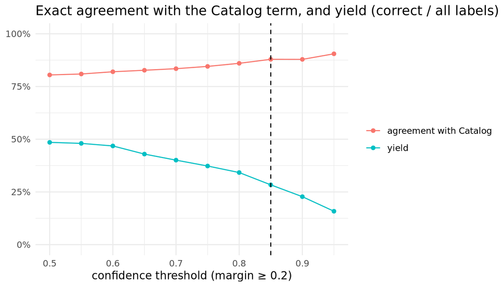

| Confidence ≥ | Promoted | Agreement | Yield |
| --- | --- | --- | --- |
| 0.50 | 1343 | 80.5% | 48.5% |
| 0.55 | 1322 | 80.9% | 48.0% |
| 0.60 | 1272 | 82.0% | 46.8% |
| 0.65 | 1157 | 82.7% | 43.0% |
| 0.70 | 1070 | 83.5% | 40.1% |
| 0.75 | 983 | 84.5% | 37.3% |
| 0.80 | 886 | 86.0% | 34.2% |
| 0.85 | 719 | 87.9% | 28.4% |
| 0.90 | 577 | 87.9% | 22.8% |
| 0.95 | 390 | 90.5% | 15.8% |

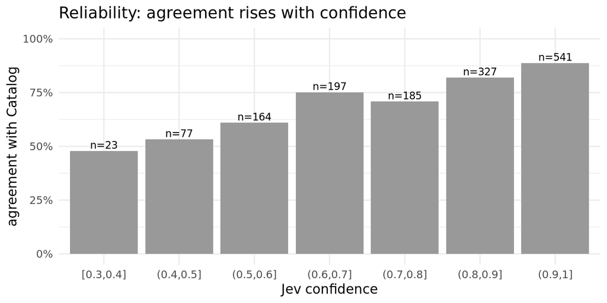

### Adjudicating the confident disagreements

We reviewed all 92 promoted-but-disagreeing picks. The Catalog’s term was sometimes itself wrong: “nonsyndromic cleft palate” is mapped to *cleft lip*, and “collagen band thickness” to *blood protein amount*.

**Note**

These verdicts were made by the AI assistant (Claude) that built the pipeline, by reading labels and term names. They are not a human curator’s review, and they are published here in full so they can be checked.

| Verdict | Labels |
| --- | --- |
| pick more specific or more accurate | 64 |
| equivalent | 20 |
| arguable | 6 |
| source better | 2 |

| Trait label | Catalog term | Jev pick | Conf. | Verdict | Note |
| --- | --- | --- | --- | --- | --- |
| a body shape index | BMI-adjusted waist circumference | body shape measurement | 0.9 | arguable | ABSI is waist circumference adjusted for BMI and height; source term closer |
| ascending aorta diameter | aortic measurement | ascending aorta diameter | 0.98 | pick more specific or more accurate |  |
| average circumferential strain of left ventricle | heart disorder | myocardial strain | 0.88 | pick more specific or more accurate | source term is a disease, not a strain measurement |
| bilateral amygdala volume | subcortical volume measurement | amygdala volume | 0.96 | pick more specific or more accurate |  |
| blood glucose levels | glucose measurement | blood glucose amount | 0.88 | equivalent |  |
| c-c motif chemokine 4 levels | C-C motif chemokine 4-like measurement | level of C-C motif chemokine 4 in blood | 0.86 | pick more specific or more accurate | source term is the CCL4-like paralogue |
| carotid intima media thickness | carotid artery thickness | carotid artery intima-media region thickness | 0.95 | pick more specific or more accurate |  |
| carotid intima media thickness (maximum) | carotid artery thickness | carotid artery intima-media region thickness | 0.94 | pick more specific or more accurate |  |
| carotid intima media thickness (mean) | carotid artery thickness | carotid artery intima-media region thickness | 0.95 | pick more specific or more accurate |  |
| carotid intima media thickness (minimum) | carotid artery thickness | carotid artery intima-media region thickness | 0.85 | pick more specific or more accurate |  |

[output cut: 82 more lines]

Counting *more specific or more accurate* and *equivalent* picks as correct, the estimated precision at the production thresholds is **98.9%**, compared with 87.8% agreement with the Catalog’s own term.

## ukb-b round 1

The ukb-b queue has 2,502 distinct labels, covering 2,514 Analyses. None was in the mapping table beforehand. The round cost $0.0965, with no failed requests.

This round used the pre-#185 pipeline (top-10 shortlists, no ICD-10 cross-reference channel, no field context). The #185 changes described in the pipeline section target the retrieval misses and context-blind abstentions this round shows.

| Outcome | Labels | Analyses |
| --- | --- | --- |
| no suitable term | 1037 | 1043 |
| review (uncertain pick) | 566 | 568 |
| review (uncertain abstention) | 490 | 492 |
| auto-accepted | 409 | 411 |

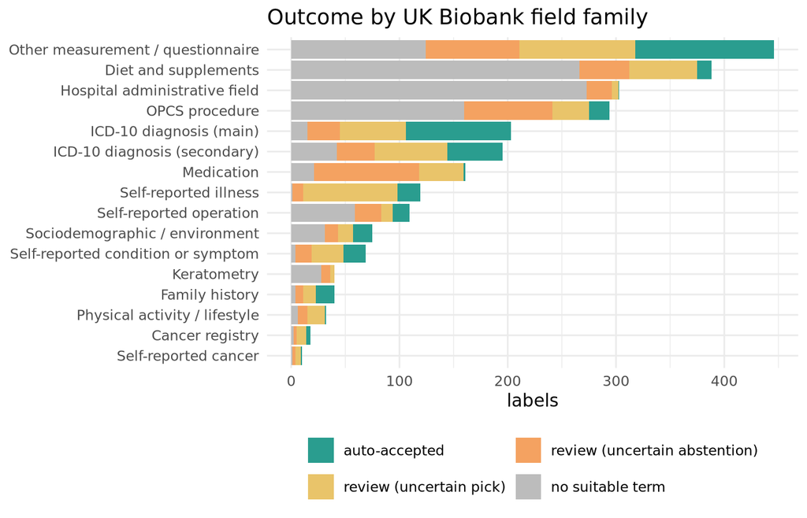

| Field family | Labels | Auto-accepted | Review: pick | Review: abstention | No suitable term |
| --- | --- | --- | --- | --- | --- |
| Other measurement / questionnaire | 446 | 128 | 107 | 87 | 124 |
| Diet and supplements | 388 | 13 | 63 | 46 | 266 |
| Hospital administrative field | 303 | 1 | 6 | 23 | 273 |
| OPCS procedure | 294 | 19 | 34 | 81 | 160 |
| ICD-10 diagnosis (main) | 203 | 97 | 61 | 30 | 15 |
| ICD-10 diagnosis (secondary) | 195 | 51 | 67 | 35 | 42 |
| Medication | 161 | 2 | 41 | 97 | 21 |
| Self-reported illness | 119 | 21 | 87 | 10 | 1 |
| Self-reported operation | 109 | 15 | 11 | 24 | 59 |
| Sociodemographic / environment | 75 | 18 | 14 | 12 | 31 |
| Self-reported condition or symptom | 69 | 21 | 29 | 15 | 4 |
| Family history | 40 | 17 | 12 | 7 | 4 |
| Keratometry | 40 | 0 | 4 | 8 | 28 |
| Physical activity / lifestyle | 32 | 1 | 16 | 9 | 6 |
| Cancer registry | 18 | 4 | 9 | 3 | 2 |
| Self-reported cancer | 10 | 1 | 5 | 3 | 1 |

Clinical codes map well: ICD-10 diagnoses, self-reported illnesses and symptoms, and family history. Diet items (“beef intake”, “dried fruit intake”) and keratometry fields mostly have no EFO term, so abstention is the right answer for them. But not every abstention is a missing term: the ICD-10-coded labels `diagnoses - main icd10: c61 malignant neoplasm of prostate`, `... k59.0 constipation`, and `... h00.1 chalazion` were abstained because no candidate was retrieved, even though EFO has terms for prostate cancer, constipation, and chalazion — their ICD-10 xrefs exist, but the label’s full text did not shortlist them at retrieval time, so the chooser never saw them. Medications are rarely auto-accepted: EFO has few drug-exposure terms, so they go to review.

**Warning303 ukb-b “traits” are hospital administrative fields**

For example: “PCT where patient’s GP was registered”, “main speciality of consultant”, and hospital admission or discharge methods. These are not phenotypes. Jev correctly declined 273 of them outright. Only one was auto-accepted: “methods of discharge: patient death” → *dead (follow-up status)*, which is defensible. These fields should arguably be excluded from the mapping queue, or from trait-level use, upstream.

### Checking a sample of auto-accepted rows

We drew a random sample of 60 of the 409 auto-accepted rows and reviewed them the same way (AI assistant review, not a human curator): 53 match the label, and 7 use a broader term where EFO has nothing more specific. For example, “qualifications: O levels” maps to *educational attainment*, and “birth weight of first child” maps to *birth weight* (EFO has no offspring-birth-weight term). None was wrong.

| Trait label | Term | Label | Conf. | Verdict | Note |
| --- | --- | --- | --- | --- | --- |
| mouth/teeth dental problems: bleeding gums | HP:0000225 | Gingival bleeding | 0.94 | matches the label |  |
| diagnoses - main icd10: n20.0 calculus of kidney | MONDO:0008171 | nephrolithiasis | 0.97 | matches the label |  |
| non-cancer illness code, self-reported: fracture wrist / colles fracture | EFO:0009515 | wrist fracture | 0.86 | matches the label |  |
| diagnoses - main icd10: k80.5 calculus of bile duct without cholangitis or cholecystitis | MONDO:0006699 | choledocholithiasis | 0.96 | matches the label |  |
| diagnoses - main icd10: o80.0 spontaneous vertex delivery | EFO:0009638 | spontaneous labor and birth | 0.93 | matches the label |  |
| operative procedures - main opcs: n30.3 circumcision | EFO:0003953 | circumcision | 0.99 | matches the label |  |
| operation code: appendicectomy | EFO:0600086 | appendectomy | 0.99 | matches the label |  |
| illnesses of mother: heart disease | EFO:0900005 | family history of heart disease | 0.85 | matches the label |  |
| average total household income before tax | EFO:0009695 | household income | 0.94 | matches the label |  |
| tea intake | EFO:0010091 | tea consumption measurement | 1 | matches the label |  |

[output cut: 50 more lines]

### All ukb-b outcomes

| Trait label | Field | Analyses | Term | Label | Conf. | Outcome |
| --- | --- | --- | --- | --- | --- | --- |
| 3mm asymmetry angle (left) | Keratometry | 1 | none_suitable |  | 0.54 | review (uncertain abstention) |
| 3mm asymmetry angle (right) | Keratometry | 1 | none_suitable |  | 0.61 | review (uncertain abstention) |
| 3mm asymmetry index (left) | Keratometry | 1 | none_suitable |  | 0.46 | review (uncertain abstention) |
| 3mm asymmetry index (right) | Keratometry | 1 | EFO:0009751 | facial asymmetry measurement | 0.68 | review (uncertain pick) |
| 3mm cylindrical power (left) | Keratometry | 1 | none_suitable |  | 1 | no suitable term |
| 3mm cylindrical power (right) | Keratometry | 1 | none_suitable |  | 0.99 | no suitable term |
| 3mm cylindrical power angle (left) | Keratometry | 1 | none_suitable |  | 1 | no suitable term |
| 3mm cylindrical power angle (right) | Keratometry | 1 | none_suitable |  | 0.99 | no suitable term |
| 3mm index of best keratometry results (left) | Keratometry | 1 | none_suitable |  | 0.59 | review (uncertain abstention) |
| 3mm index of best keratometry results (right) | Keratometry | 1 | none_suitable |  | 0.53 | review (uncertain abstention) |

[output cut: 2492 more lines]

## Limitations and next steps

- **The review queue is unreviewed.** 1,056 ukb-b labels are waiting for a human curator. The reviewed-queue round trip (accept, amend, reject) is implemented but has not been used on real data yet.
- **Adjudication was done by AI.** The disagreement and sample verdicts are the assistant’s, not a curator’s. A human spot check of the auto-accepted rows in PR #180 should come before relying on them widely.
- **Retrieval is the ceiling.** Round 1’s recall@10 was 74.5% at a top-10 shortlist. Issue #185 raises the shortlist to 100 and adds the ICD-10 cross-reference channel and the phenotype-only candidate space, which attack exactly this ceiling; the next ukb-b round will measure the gain.
- **The Catalog is a silver standard.** Exact agreement understates precision. Some Catalog mappings are coarser than the label, and a few are simply wrong.
- **Lower thresholds may be viable.** Agreement at confidence ≥ 0.7 is 83.5% against the Catalog, before adjudication. Adjudicating that band would show whether the threshold can drop and raise yield.
- **The `none_suitable` list is not all missing terms.** It mixes labels EFO genuinely has no term for (individual foods, keratometry fields, hospital administrative fields) with retrieval misses — labels whose term exists in EFO but was not shortlisted, such as the ICD-10 codes C61 (prostate cancer), K59.0 (constipation), and H00.1 (chalazion); see the ukb-b section. Mapping the first group needs new EFO terms (an upstream request) or a non-EFO target; the second group may map once #185 lands, so a better chooser is not ruled out.

## Reproducing

```bash
# once per EFO release (TEI serving BioLORD-2023 on localhost:8080)
pixi run -e curation ontology-index --obo efo.obo --release efo/v3.94.0 \
    --output .cache/curation/efo-v3.94.0.index.json
pixi run -e curation embed-ontology --ontology-index .cache/curation/efo-v3.94.0.index.json \
    --output .cache/curation/efo-v3.94.0--BioLORD-2023.ontology-embeddings

# a round (production: --manifests; validation: --queue-tsv from `harvest`)
pixi run -e curation round-init --round-dir <dir> --index <index> \
    --ontology-embeddings <store> --chooser jev --manifests <analyses.tsv> \
    --ukb-showcase-dir .cache/curation/ukb-showcase \
    --threshold-evidence "<calibration>"
for step in gap-scan embed-traits candidates; do pixi run -e curation round-$step --round-dir <dir>; done
pixi run -e curation round-choose --round-dir <dir> --workers 8 --max-cost-usd 1
pixi run -e curation round-reduce --round-dir <dir>
pixi run -e curation round-promote --round-dir <dir>

# this report's data, then the page
pixi run -e curation python resources/scripts/export-trait-mapping-report.py \
    --index <index> --validation <ogs-00011.tsv> \
    --validation-round <validation dir> --production-round <ukb-b dir>
pixi run --environment docs quarto render resources/scripts/trait-mapping-report.qmd --to html
```

Pins for both rounds: EFO efo/v3.94.0; FremyCompany/BioLORD-2023 (ontology store blake2b:5328e64d77fdaf5847e565c01bb94c2d); Jev jev-1.13.0. Round 1 used shortlist size 10; the default is now 100 and the Showcase directory is pinned via `--ukb-showcase-dir` (issue #185).